# Лабораторная работа №5

Основы информационной безопасности

Мурашов И. В., НКАбд-03-23

Российский университет дружбы народов, Москва, Россия

19 апреля 2025

## Докладчик

- Мурашов Иван Вячеславович
- Cтудент, 2 курс, группа НКАбд-03-23
- Российский университет дружбы народов
- 1132236018@rudn.ru
- https://neve7mind.github.io

## Цель работы

Изучение механизмов изменения идентификаторов, применения SetUID- и Sticky-битов. Получение практических навыков работы в кон- соли с дополнительными атрибутами. Рассмотрение работы механизма смены идентификатора процессов пользователей, а также влияние бита Sticky на запись и удаление файлов.

## Выполнение лабораторной работы

Для лабораторной работы необходимо проверить, установлен ли компилятор gcc, комнда `gcc -v` позволяет это сделать. Также осуществляется отключение системы запретом с помощью `setenforce 0` (рис. 1).

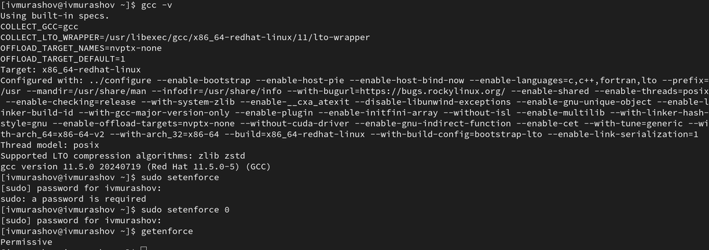

Подготовка к лабораторной работе

## Выполнение лабораторной работы

Осуществляется вход от имени пользователя guest (рис. 2).

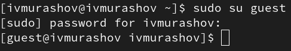

Вход от имени пользователя guest

## Выполнение лабораторной работы

Создание файла simpled.c и запись в файл кода (рис. 3)

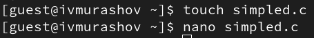

Создание файла

## Выполнение лабораторной работы

`C++ Листинг 1 #include <sys/types.h> #include <unistd.h> #include <stdio.h> int main () { uid_t uid = geteuid (); gid_t gid = getegid (); printf ("uid=%d, gid=%d\n", uid, gid); return 0; }`

## Выполнение лабораторной работы

Cодержимое файла выглядит следующти образом (рис. 4)

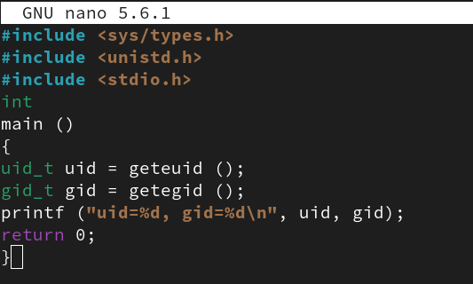

Содержимое файла

## Выполнение лабораторной работы

Компилирую файл, проверяю, что он скомпилировался (рис. 5)

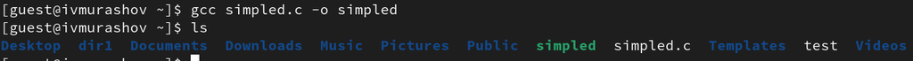

Компиляция файла

## Выполнение лабораторной работы

Запускаю исполняемый файл. В выводе файла выписыны номера пользоватея и групп, от вывода при вводе if, они отличаются только тем, что информации меньше (рис. 6)

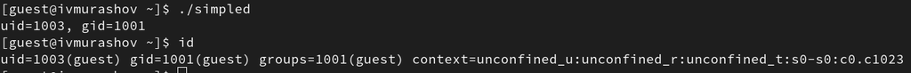

Сравнение команд

## Выполнение лабораторной работы

Создание, запись в файл и компиляция файла simpled2.c. Запуск программы (рис. 7)

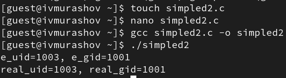

Создание и компиляция файла

## Выполнение лабораторной работы

`C++ Листинг 2 #include <sys/types.h> #include <unistd.h> #include <stdio.h> int main () { uid_t real_uid = getuid (); uid_t e_uid = geteuid (); gid_t real_gid = getgid (); gid_t e_gid = getegid () ; printf ("e_uid=%d, e_gid=%d\n", e_uid, e_gid); printf ("real_uid=%d, real_gid=%d\n", real_uid, real_gid); return 0; }`

(рис. 8)

## Выполнение лабораторной работы

[figure not shown]

Содержимое файла

## Выполнение лабораторной работы

С помощью chown изменяю владельца файла на суперпользователя, с помощью chmod изменяю права доступа (рис. 9)

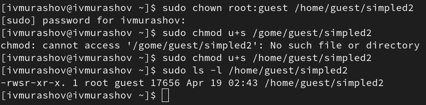

Смена владельца файла и прав доступа к файлу

## Выполнение лабораторной работы

Сравнение вывода программы и команды id, наша команда снова вывела только ограниченное количество информации(рис. 10)

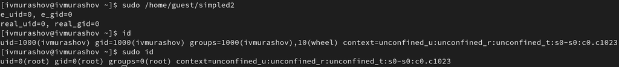

Запуск файла

## Выполнение лабораторной работы

Создание и компиляция файла readfile.c (рис. 11)

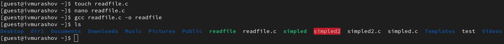

Создание и компиляция файла

## Выполнение лабораторной работы

`C++ Листинг 3 #include <fcntl.h> #include <stdio.h> #include <sys/stat.h> #include <sys/types.h> #include <unistd.h> int main (int argc, char* argv[]) { unsigned char buffer[16]; size_t bytes_read; int i; int fd = open (argv[1], O_RDONLY);c do { bytes_read = read (fd, buffer, sizeof (buffer)); for (i =0; i < bytes_read; ++i) printf("%c", buffer[i]); } while (bytes_read == sizeof (buffer)); close (fd); return 0; }`

## Выполнение лабораторной работы

(рис. 12)

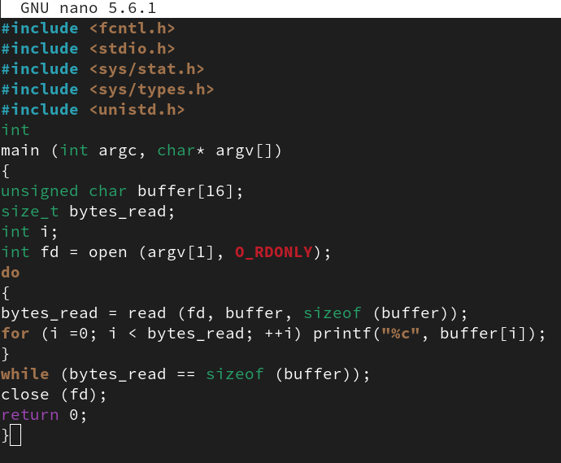

Содержимое файла

## Выполнение лабораторной работы

Снова от имени суперпользователи меняю владельца файла readfile. Далее меняю права доступа так, чтобы пользователь guest не смог прочесть содержимое файла (рис. 13)

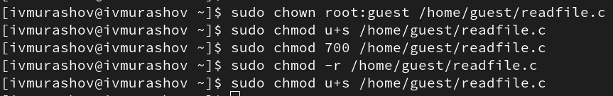

Смена владельца файла и прав доступа к файлу

## Выполнение лабораторной работы

Проверка прочесть файл от имени пользователя guest. Прочесть файл не удается (рис. 14)

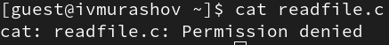

Попытка прочесть содержимое файла

## Выполнение лабораторной работы

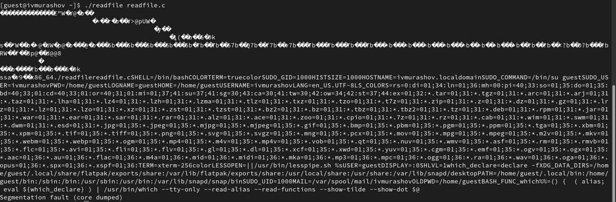

Попытка прочесть содержимое файла программой

## Выполнение лабораторной работы

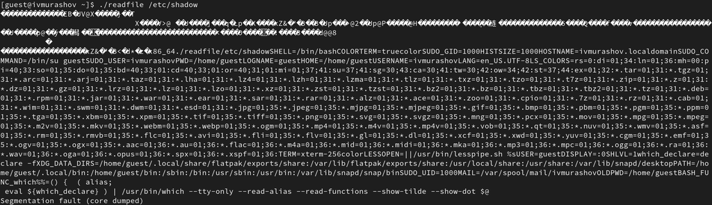

Попытка прочесть содержимое файла программой

## Выполнение лабораторной работы

Пробуем прочесть эти же файлы от имени суперпользователя и чтение файлов проходит успешно (рис. 17)

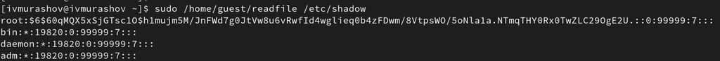

Чтение файла от имени суперпользователя

## Выполнение лабораторной работы

Проверяем папку tmp на наличие атрибута Sticky, т.к. в выводе есть буква t, то атрибут установлен (рис. 18)

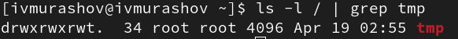

Проверка атрибутов директории tmp

## Выполнение лабораторной работы

От имени пользователя guest создаю файл с текстом, добавляю права на чтение и запись для других пользователей (рис. 19)

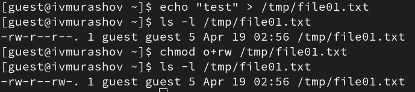

Создание файла, изменение прав доступа

## Выполнение лабораторной работы

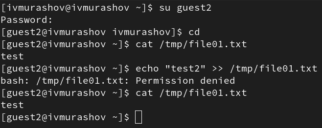

Попытка чтения файла

## Выполнение лабораторной работы

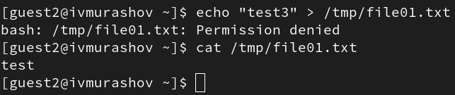

Попытка записи в файл

## Выполнение лабораторной работы

Далее пробуем удалить файл, снова получаем отказ (рис. 22)

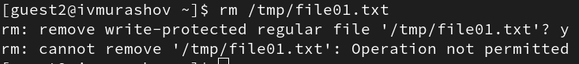

Попытка удалить файл

## Выполнение лабораторной работы

От имени суперпользователя снимаем с директории атрибут Sticky (рис. 23)

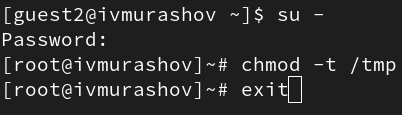

Смена атрибутов файла

## Выполнение лабораторной работы

Проверяем, что атрибут действительно снят (рис. 24)

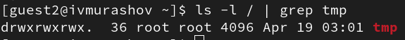

Проверка атрибутов директории

## Выполнение лабораторной работы

Далее был выполнен повтор предыдущих действий. По результатам без Sticky-бита запись в файл и дозапись в файл осталась невозможной, зато удаление файла прошло успешно (рис. 25)

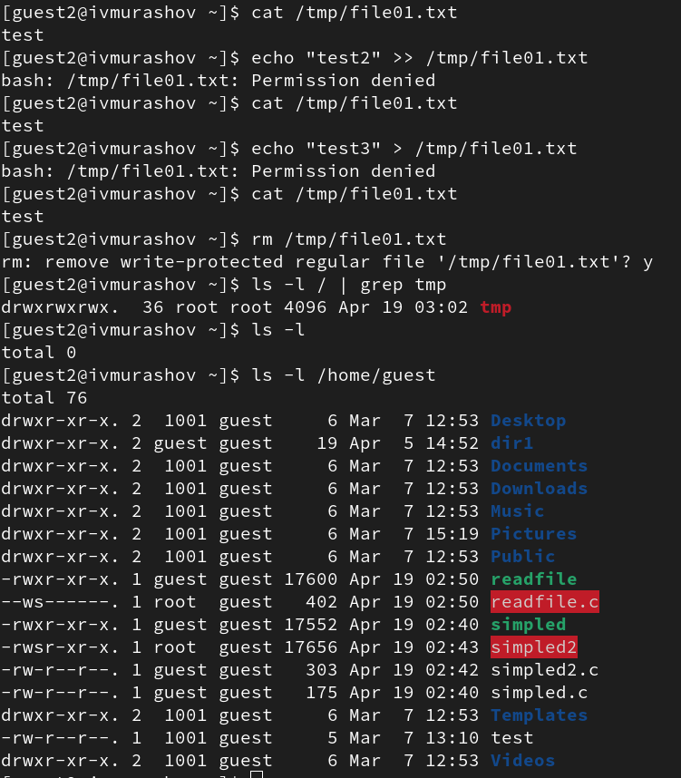

Повтор предыдущих действий

## Выполнение лабораторной работы

Возвращение директории tmp атрибута t от имени суперпользователя (рис. 26)

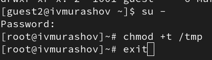

Изменение атрибутов

# Выводы

Я изучил механизм изменения идентификаторов, применила SetUID- и Sticky-биты. Получил практические навыки работы в кон- соли с дополнительными атрибутами. Рассмотрел работы механизма смены идентификатора процессов пользователей, а также влияние бита Sticky на запись и удаление файлов.